[figure not shown]

# Introduction to Logistic Regression

# Icebreaker

Today we will deal with **binary** classification problems, and also talk about **imbalanced classes**.

With your neighbour, discuss 1-2 cases of **binary** classification problems where there is a large imbalance (i.e. much more positives than negatives or vice versa).

## Agenda / Learning Objectives

### Part 1: Introduction to Logistic Regression

### Part 2: Imbalanced Classes

### Part 3: Exercise

# Introduction to Logistic Regression

`Linear Regression` is used to predict a value

We start from several attributes and we linearly interpolate them in order to predict our target

`Logistic Regression` is used to predict the probability of this value belonging to a certain class

In other words, once we predict our target, we'd like to

- categorise our target (i.e., assigning it a label)
- calculate the probability of this target to belong to a specific label

This class (or label) could be:

- boolean (True or False)
- multinomial (Red, Green, Blue...)
- ordinal (first, second, third...)

Could we use it for **classification**?

Example: for a **binary** problem, why not use linear regression to model the **probability** that a data point is in one class?

- by definition we would also model the probability of it being in the other class too

What decision would we need to make for this to work for prediction?

- a **cutoff point** i.e. a probability above which we say class 1 vs. 0

### Example: bikeshare.csv

Question: Will `many bikes` be rented in a specific hour?

Set a cutoff point in the bikeshare dataframe to divide the entries into 2 classes:

- hours with `many bikes rented` (> 200)
- hours with `few bikes rented` (<= 200)

So the answer to the question can only be **yes** or **no** (boolean problem).

```python
import pandas as pd
import numpy as np
import matplotlib.pyplot as plt
%matplotlib inline
```

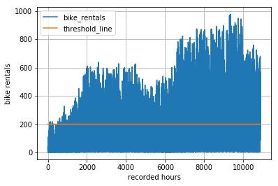

```python
bikeshare = pd.read_csv("assets/data/bikeshare.csv")

# this threshold sets the limit between 'many bikes rented' and 'few bikes rented'
rental_threshold = 200

threshold_line = np.linspace(rental_threshold, rental_threshold, len(bikeshare))
plt.plot(bikeshare['count'], label='bike_rentals')
plt.plot(threshold_line, label='threshold_line')
plt.grid()
plt.legend(loc=2)
plt.xlabel('recorded hours')
plt.ylabel('bike rentals')
plt.show()
```

Linear regression itself does not return probabilities.

Say that $z$ is our linear model is:

$$ z = \beta_0 + \beta_1x_1 + \beta_2x_2 ... $$

We could, for example, base our model on the temperature

So we would predict the number of rented bikes based on temperature

With a simple transformation we can 'squash' our line to be between 0 and 1:

$$ \text{p} = \frac{1}{1 + e^{-z}} $$

This is how we extract probability from `Linear Regression`

### Explanation

This is how our `Linear Regression` model looks like.

[figure not shown]

This is how we change the `Linear Regression` model into a `Classification` dataset, by setting a cutoff.

[figure not shown]

And finally, this is how our dataset looks like, once we convert the data-points into a binary system.

[figure not shown]

In other words, based on the recorded temperature, we can tell:

- if in a hour `many bikes` will be rented or not
- the probability of our prediction

So what is our linear equation modelling now?

Rearranging the logistic equation gives us:

$$ \text{p} = \frac{1}{1 + e^{-z}} $$

$$ z = \beta_0 + \beta_1x_1 + \beta_2x_2 ... = log(\frac{p}{1-p}) $$

This is the "log odds"

### Odds

When we say the "odds" of something, what do we mean?

The odds are the probability of something happening divided by the probability of it **not** happening

#### Odds

$$ \text{odds} = \frac{p}{1-p} $$

$$ p = \frac{\text{odds}}{1+\text{odds}} $$

```python
def p_to_odds(p):
    return p / (1 - p)

def odds_to_p(odds):
    return odds / (1 + odds)

odds = {"country": ["Brazil", "Germany", "Spain", "South Korea"], "odds": [2/7, 2/9, 2/11, 1/750]}
```

```python
df_odds = pd.DataFrame(odds)
df_odds["p"] = df_odds["odds"].apply(odds_to_p)
df_odds
```

|  | country | odds | p |
| --- | --- | --- | --- |
| 0 | Brazil | 0.285714 | 0.222222 |
| 1 | Germany | 0.222222 | 0.181818 |
| 2 | Spain | 0.181818 | 0.153846 |
| 3 | South Korea | 0.001333 | 0.001332 |

## Logistic Regression in Python

```python
bikeshare = pd.read_csv("assets/data/bikeshare.csv")

# create column "many_bikes"
rental_threshold = 200
bikeshare.loc[bikeshare['count'] > rental_threshold, "many_bikes"] = True
bikeshare.loc[bikeshare['count'] <= rental_threshold, "many_bikes"] = False

bikeshare.head()
```

|  | datetime | season | holiday | workingday | weather | temp | atemp | humidity | windspeed | casual | registered | count | many_bikes |
| --- | --- | --- | --- | --- | --- | --- | --- | --- | --- | --- | --- | --- | --- |
| 0 | 2011-01-01 00:00:00 | 1 | 0 | 0 | 1 | 9.84 | 14.395 | 81 | 0.0 | 3 | 13 | 16 | False |
| 1 | 2011-01-01 01:00:00 | 1 | 0 | 0 | 1 | 9.02 | 13.635 | 80 | 0.0 | 8 | 32 | 40 | False |
| 2 | 2011-01-01 02:00:00 | 1 | 0 | 0 | 1 | 9.02 | 13.635 | 80 | 0.0 | 5 | 27 | 32 | False |
| 3 | 2011-01-01 03:00:00 | 1 | 0 | 0 | 1 | 9.84 | 14.395 | 75 | 0.0 | 3 | 10 | 13 | False |
| 4 | 2011-01-01 04:00:00 | 1 | 0 | 0 | 1 | 9.84 | 14.395 | 75 | 0.0 | 0 | 1 | 1 | False |

```python
# let's choose to use temperature to predict the class of rented bikes

x_bike = bikeshare[['temp']]
y_bike = bikeshare['many_bikes']
```

#### Convert targets to binary

`True` values will become 1, `False` values will become 0.

```python
from sklearn.preprocessing import LabelBinarizer

lb = LabelBinarizer()
lb.fit_transform(y_bike)[:5]
```

```
array([[0],
       [0],
       [0],
       [0],
       [0]])
```

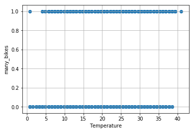

```python
plt.scatter(x_bike, y_bike)
plt.grid()
plt.xlabel("Temperature")
plt.ylabel("many_bikes")
plt.show()
```

```python
from sklearn.linear_model import LogisticRegression
from sklearn.model_selection import train_test_split

lr = LogisticRegression()
X_train, X_test, y_train, y_test = train_test_split(x_bike,
                                                    y_bike,
                                                    test_size=0.25,
                                                    random_state=42)
lr.fit(X_train, y_train)

print(lr.intercept_, lr.coef_)
```

```
[-2.64581324] [[0.10448876]]
```

### Interpretation

- coefficients are on the **log odds** scale
- so an increase in 1 degree Celsius increases the log odds of renting `many_bikes` by 0.104

#### While log odds values are linear...

(and can be negative)

```python
log_odds_temp_2c = lr.intercept_ + 2*lr.coef_[0][0]
log_odds_temp_3c = lr.intercept_ + 3*lr.coef_[0][0]
log_odds_temp_4c = lr.intercept_ + 4*lr.coef_[0][0]
log_odds_temp_5c = lr.intercept_ + 5*lr.coef_[0][0]

print(log_odds_temp_2c, log_odds_temp_3c, log_odds_temp_4c, log_odds_temp_5c)
```

```
[-2.43683572] [-2.33234695] [-2.22785819] [-2.12336943]
```

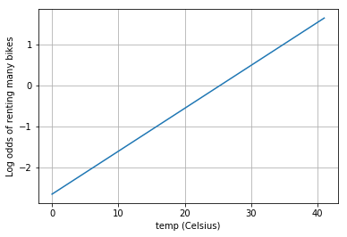

```python
x_values_to_plot = np.linspace(0, x_bike.max(), 100)
y_values_to_plot = (x_values_to_plot * lr.coef_[0]) + lr.intercept_


plt.plot(x_values_to_plot, y_values_to_plot)
plt.grid()
plt.xlabel('temp (Celsius)')
plt.ylabel('Log odds of renting many bikes')
plt.show()
```

#### Probabilities are not!

(and they are always positive)

```python
print(odds_to_p(np.exp(log_odds_temp_2c)),
      odds_to_p(np.exp(log_odds_temp_3c)),
      odds_to_p(np.exp(log_odds_temp_4c)),
      odds_to_p(np.exp(log_odds_temp_5c)))
```

```
[0.08040657] [0.0884792] [0.09727656] [0.1068461]
```

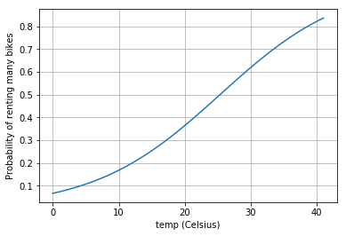

```python
def sigmoid(z):
    return 1.0 / (1 + np.exp(-z))

fig, ax = plt.subplots()
ax.plot(x_values_to_plot, [sigmoid(x) for x in y_values_to_plot])
plt.grid()
plt.xlabel('temp (Celsius)')
plt.ylabel('Probability of renting many bikes')

plt.show()
```

#### What to remember

- coefficients change the **log odds**
- you can convert log odds to probabilities, but the odds-to-probability scale is **not linear**
  - a 1 unit increase in log odds doesn't always give the same increase in probability
- positive coefficients increase log odds and therefore increase probability
- negative coefficients decrease log odds and therefore decrease probability

Further reading and examples

https://eight2late.wordpress.com/2017/07/11/a-gentle-introduction-to-logistic-regression-and-lasso-regularisation-using-r/

### What happens if you change the cutoff for `many_bikes` ?

Try increasing and decreasing the cutoff

### What happens if you use another feature instead of temperature?

Can humidity or windspeed be a better predictor? Can they maximise the probability of renting `many bikes`?

# Imbalanced Classes

What can you do when there is a class imbalance?

- do nothing (and hope for the best)

Balance the training set by either:

- Oversampling the minority class
- Undersampling the majority class
- Creating new samples (by interpolation)

[figure not shown]

- tell your algorithm to weight the classes differently

```
LogisticRegression(class_weight="balanced")
LogisticRegression(class_weight={0: 100, 1: 200})
```

Recommended reading: https://www.svds.com/learning-imbalanced-classes